# Exercício de aplicação do DIC e DBC

Gleynner Ghiotto

# 1 **Exercício proposto para o DIC**

Suponha que um melhorista de milho desenvolveu quatro híbridos *h1*, *h2*, *h3* e *h4*. Esses híbridos foram identificados de acordo com os potenciais produtivos das linhagens que os originaram, ou seja, espera-se que o híbrido *h1* seja o mais produtivo e o híbrido *h4* seja o menos produtivo. O melhorista, com base em conhecimento prévio, define a unidade experimental (UE) como sendo uma área de 4 m<sup>2</sup> (constituída de 25 plantas) e distribui os híbridos às unidades experimentais de forma aleatória. Identifique o híbrido que apresenta a maior média de produção de grãos (kg).

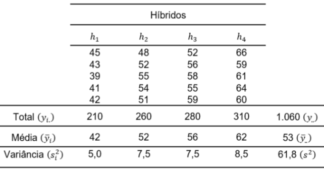

## 1.1 Dados do probelma

```r
# Dados do problema
trat <- factor(rep(c("h1", "h2", "h3", "h4"),  each = 5))
y <- c(45,43,39,41,42,48,52,55,54,51, 52,56,58,55,59, 66,59,61,64,60)
res <- residuals(lm(y ~ trat)) %>% round(2)
df_dic <- data.frame(trat,y,res)

head(df_dic)
```

|  | trat | y | res |
| --- | --- | --- | --- |
| 1 | h1 | 45 | 3 |
| 2 | h1 | 43 | 1 |
| 3 | h1 | 39 | -3 |
| 4 | h1 | 41 | -1 |
| 5 | h1 | 42 | 0 |
| 6 | h2 | 48 | -4 |

## 1.2 Suposições para a realização da ANOVA:

### 1.2.1 Os erros seguem distribuição normal

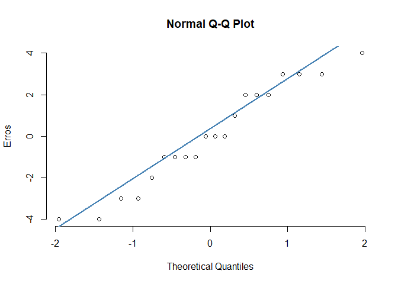

```r
# Obs.: no R notebook, executar qqnorm e qqline simultaneamente.
qqnorm(df_dic$res, pch = 1, frame = FALSE,  ylab = "Erros")
qqline(df_dic$res, col = "steelblue", lwd = 2)
```

```r
# Teste de normalidade de Shapiro-Wilk
shapiro.test(df_dic$res)
```

```
    Shapiro-Wilk normality test

data:  df_dic$res
W = 0.9465, p-value = 0.3171
```

```r
# H0: os erros aleatórios seguem uma distribuição normal
# Ha: os erros aleatórios não seguem uma distribuição normal
```

Valor de *p* igual a 0,3171 (*p* > 0,05), logo, não significativo. Isto indica que os dados seguem distribuição normal (hipótese H<sub>0</sub> é verdadeira).

### 1.2.2 Os erros devem apresentar variâncias homogêneas

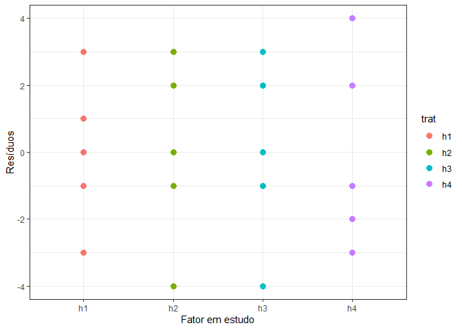

```r
# Dispersão dos resíduos por tratamento
ggplot(data = df_dic) +
  geom_point(aes(x = trat, y=res, color = trat), size = 3) +
  labs(x = "Fator em estudo", y = "Resíduos") +
  theme_bw()
```

```r
# teste de Bartlett para homogeneidade de variâncias
bartlett.test(res ~ trat, data = df_dic)
```

```
    Bartlett test of homogeneity of variances

data:  res by trat
Bartlett's K-squared = 0.27216, df = 3, p-value = 0.9652
```

```r
# H0: os i tratamentos possuem variâncias homogêneas
# Ha: a variância de pelo menos um dos tratamentos se difere dos demais
```

Valor *p* > 0,05, logo, o teste é não signicativo (isto é, as variâncias amostrais são homogêneas).

### 1.2.3 Os erros são independentes

O uso da casualização faz com que a estimativa do erro experimental seja válida, além de fazer com que as amostras sejam independentes.

## 1.3 Análise de variância (ANOVA)

```r
# Teste ANOVA
anova.dic <-aov(y ~ trat, data = df_dic)
saida.dic <- summary(anova.dic);saida.dic # summary() retorna uma lista
```

```
            Df Sum Sq Mean Sq F value   Pr(>F)
trat         3   1060   353.3   49.59 2.52e-08 ***
Residuals   16    114     7.1
---
Signif. codes:  0 '***' 0.001 '**' 0.01 '*' 0.05 '.' 0.1 ' ' 1
```

*p* ≤ 0,05, portanto, o teste é significativo.

```r
#str(saida.dic)
str(saida.dic[[1]])
```

```
Classes 'anova' and 'data.frame':   2 obs. of  5 variables:
 $ Df     : num  3 16
 $ Sum Sq : num  1060 114
 $ Mean Sq: num  353.33 7.12
 $ F value: num  49.6 NA
 $ Pr(>F) : num  2.52e-08 NA
```

```r
sq.res <- saida.dic[[1]]$`Sum Sq`[2]
gl.res <- saida.dic[[1]]$Df[2]

#Teste de Tukey - expdes.pt
tukey(y, trat, DFerror = gl.res, SSerror = sq.res, alpha = 0.05)
```

```
Teste de Tukey
------------------------------------------------------------------------
Grupos Tratamentos Medias
a    h4      62
 b   h3      56
 b   h2      52
  c      h1      42
------------------------------------------------------------------------
```

Como o teste da ANOVA foi significativo (*p* ≤ 0,05), pelo menos uma das médias difere das demais. Por meio de teste de comparação de médias de Tukey é possível observar que o híbrido 4 é o que apresenta maior média de produção de grãos.

## 1.4 Coeficiente de variação

```r
qm.res <- saida.dic[[1]]$`Mean Sq`[2]
m <- mean(df_dic$y)

cv <- sqrt(qm.res)/m; cv
```

```
## [1] 0.05036358
```

```r
#    CV           Precisão
#  < 10%           Alta
#  10 a 20%        Média
#  20 a 30%        Baixa
#  > 30%           Muito Baixa
```

Como o coeficiente de variação foi igual a 5,04% o experimento foi de alta precisão.

# 2 **Exercício proposto para o DBC**

Suponha que um melhorista estuda os mesmos quatro híbridos de milho (*h1*, *h2*, *h3* e *h4*) do exercício anterior, contudo, agora a área experimental não é mais uniforme e se divide em dois blocos de áreas homogêneas. Para cada bloco o melhorista distribui os híbridos às unidades experimentais de forma aleatória. Sabendo disso, identifique o híbrido que apresenta a maior média de produção de grãos (kg).

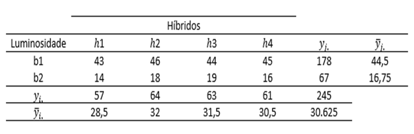

Para resolver esse exercício foi considerado que todas as pressuposições foram satisfeitas.

## 2.1 Dados do probelma

```r
# Dados do problema
trat <- factor(rep(c("h1", "h2", "h3", "h4"),times = 2))
bloco <- factor(rep(c(1, 2),each = 4))
y <- c(43,46,44,45,14,18,19,16)
df_dbc <- data.frame(trat,bloco,y); df_dbc
```

| trat | bloco | y |
| --- | --- | --- |
| h1 | 1 | 43 |
| h2 | 1 | 46 |
| h3 | 1 | 44 |
| h4 | 1 | 45 |
| h1 | 2 | 14 |
| h2 | 2 | 18 |
| h3 | 2 | 19 |
| h4 | 2 | 16 |

## 2.2 Análise de variância (ANOVA)

```r
# Teste ANOVA
anova.dbc <-aov(y ~ trat + bloco, data = df_dbc)
saida.dbc <- summary(anova.dbc);saida.dbc # summary() retorna uma lista
```

```
            Df Sum Sq Mean Sq F value   Pr(>F)
trat         3   14.4     4.8   2.674     0.22
bloco        1 1540.1  1540.1 859.605 8.71e-05 ***
Residuals    3    5.4     1.8
---
Signif. codes:  0 '***' 0.001 '**' 0.01 '*' 0.05 '.' 0.1 ' ' 1
```

Como o valor de *p* é igual a 0,22 (*p* > 0,05), os híbridos possuem a mesma média de produção de grãos (hipótese H0 é verdadeira).

## 2.3 Coeficiente de variação

```r
qm.res <- saida.dbc[[1]]$`Mean Sq`[3]
m <- mean(df_dbc$y)
cv <- sqrt(qm.res)/m; cv
```

```
## [1] 0.04370715
```

```r
#    CV           Precisão
#  < 10%           Alta
#  10 a 20%        Média
#  20 a 30%        Baixa
#  > 30%           Muito Baixa
```

O coeficiente de variação é igual a 4,37%, o experimento foi realizado com alta precisão.